# getting-started

[figure not shown]

**The FinanceToolkit** is an open-source toolkit in which all relevant financial ratios (50+), indicators and performance measurements are written down in the most simplistic way allowing for complete transparency of the calculation method. This allows you to not have to rely on metrics from other providers and, given a financial statement, allow for efficient manual calculations. This leads to one uniform method of calculation being applied that is available and understood by everyone.

1. Installation
2. The Toolkit Module
3. The Ratios Module
4. The Models Module
5. Calling Functions Directly

# Installation

To install the FinanceToolkit it simply requires the following:

```
pip install financetoolkit -U
```

From within Python use:

```
from financetoolkit import Toolkit
```

To be able to get started, you need to obtain an API Key from FinancialModelingPrep. This is used to gain access to 30+ years of financial statement both annually and quarterly. Note that the Free plan is limited to 250 requests each day, 5 years of data and only features companies listed on US exchanges.

Obtain an API Key from FinancialModelingPrep [here](https://site.financialmodelingprep.com/developer/docs/pricing/jeroen/).

Through the link you are able to subscribe for the free plan and also premium plans at a *15% discount*. This is an affiliate link and thus supports the project at the same time. I have chosen FinancialModelingPrep as a source as I find it to be the most transparent, reliable and at an affordable price. When you notice that data is inaccurate or have any other issue related to the data, note that I simply provide the means to access this data and I am not responsible for the accuracy of the data itself. For this, use [their contact form](https://site.financialmodelingprep.com/contact) or provide the data yourself.

```python
import pandas as pd
import numpy as np

from financetoolkit import Toolkit

API_KEY = "FMP_KEY"
```

# The Toolkit Module

Initializing only is required once. This is the case for any function so once you have obtained a balance sheet statement, it will be stored accordingly which means that requests to FinancialModelingPrep, the source used in these examples, are kept to a minimum. Note that in this example annual data is used but by adding `quarterly=True` to the Toolkit initialization, quarterly data can also be collected. Note that this requires a Premium subscription from FMP.

```python
# Initialize the Toolkit with company tickers
companies = Toolkit(
    ["AAPL", "MSFT", "GOOGL", "AMZN"], api_key=API_KEY, start_date="2000-01-01"
)
```

| Date | Adj Close AAPL | Adj Close AMZN | Adj Close GOOGL | Adj Close MSFT | Close AAPL | Close AMZN | Close GOOGL | Close MSFT | High AAPL | High AMZN | ... | Low GOOGL | Low MSFT | Open AAPL | Open AMZN | Open GOOGL | Open MSFT | Volume AAPL | Volume AMZN | Volume GOOGL | Volume MSFT |
| --- | --- | --- | --- | --- | --- | --- | --- | --- | --- | --- | --- | --- | --- | --- | --- | --- | --- | --- | --- | --- | --- |
| 2023-07-18 | 193.729996 | 132.830002 | 123.760002 | 359.489990 | 193.729996 | 132.830002 | 123.760002 | 359.489990 | 194.330002 | 133.860001 | ... | 122.959999 | 342.170013 | 193.350006 | 132.710007 | 124.599998 | 345.829987 | 48353800 | 54969100 | 26226400.0 | 64872700 |
| 2023-07-19 | 195.100006 | 135.360001 | 122.029999 | 355.079987 | 195.100006 | 135.360001 | 122.029999 | 355.079987 | 198.229996 | 135.990005 | ... | 121.800003 | 352.440002 | 193.100006 | 133.389999 | 124.599998 | 361.750000 | 80507300 | 54531000 | 37224000.0 | 39732900 |
| 2023-07-20 | 193.130005 | 129.960007 | 119.199997 | 346.869995 | 193.130005 | 129.960007 | 119.199997 | 346.869995 | 196.470001 | 134.789993 | ... | 118.220001 | 345.369995 | 195.089996 | 134.070007 | 121.419998 | 353.570007 | 59581200 | 59820600 | 37906800.0 | 33778400 |
| 2023-07-21 | 191.940002 | 130.000000 | 120.019997 | 343.769989 | 191.940002 | 130.000000 | 120.019997 | 343.769989 | 194.970001 | 131.369995 | ... | 118.730003 | 339.829987 | 194.100006 | 131.339996 | 120.620003 | 349.149994 | 71917800 | 133265000 | 72937900.0 | 69368900 |
| 2023-07-24 | 192.750000 | 128.800003 | 121.529999 | 345.109985 | 192.750000 | 128.800003 | 121.529999 | 345.109985 | 194.910004 | 131.660004 | ... | 120.980003 | 342.309998 | 193.410004 | 130.309998 | 121.660004 | 345.850006 | 45377800 | 45591100 | 29686100.0 | 26678100 |
| 2023-07-25 | 193.619995 | 129.130005 | 122.209999 | 350.980011 | 193.619995 | 129.130005 | 122.209999 | 350.980011 | 194.440002 | 129.580002 | ... | 121.019997 | 345.070007 | 193.330002 | 129.309998 | 121.360001 | 347.109985 | 37283200 | 39236700 | 52509600.0 | 41637700 |
| 2023-07-26 | 194.500000 | 128.149994 | 129.270004 | 337.769989 | 194.500000 | 128.149994 | 129.270004 | 337.769989 | 195.639999 | 129.080002 | ... | 128.320007 | 333.109985 | 193.669998 | 126.510002 | 130.070007 | 341.440002 | 47471900 | 53910100 | 61682100.0 | 58383700 |
| 2023-07-27 | 193.220001 | 128.250000 | 129.399994 | 330.720001 | 193.220001 | 128.250000 | 129.399994 | 330.720001 | 197.199997 | 132.630005 | ... | 128.789993 | 329.049988 | 196.020004 | 131.000000 | 131.669998 | 340.480011 | 47460200 | 52610700 | 44952100.0 | 39635300 |
| 2023-07-28 | 195.830002 | 132.210007 | 132.580002 | 338.369995 | 195.830002 | 132.210007 | 132.580002 | 338.369995 | 196.630005 | 133.009995 | ... | 130.570007 | 333.170013 | 194.669998 | 129.690002 | 130.779999 | 333.670013 | 48254600 | 46234700 | 36572900.0 | 28463000 |
| 2023-07-31 | 196.449997 | 133.679993 | 132.720001 | 335.920013 | 196.449997 | 133.679993 | 132.720001 | 335.920013 | 196.490005 | 133.869995 | ... | 131.779999 | 333.359985 | 196.059998 | 133.199997 | 132.729996 | 336.920013 | 38778100 | 41821800 | 28037700.0 | 25421600 |

10 rows × 24 columns

| Date | Adj Close AAPL | Adj Close AMZN | Adj Close GOOGL | Adj Close MSFT | Close AAPL | Close AMZN | Close GOOGL | Close MSFT | High AAPL | High AMZN | ... | Low GOOGL | Low MSFT | Open AAPL | Open AMZN | Open GOOGL | Open MSFT | Volume AAPL | Volume AMZN | Volume GOOGL | Volume MSFT |
| --- | --- | --- | --- | --- | --- | --- | --- | --- | --- | --- | --- | --- | --- | --- | --- | --- | --- | --- | --- | --- | --- |
| 1999 | 0.780221 | 3.806250 | NaN | 36.340618 | 0.917969 | 3.806250 | NaN | 58.375000 | 0.918527 | 3.968750 | ... | NaN | 58.125000 | 0.901228 | 3.965625 | NaN | 58.750000 | 163811200 | 145414000 | NaN | 12517600 |
| 2000 | 0.225766 | 0.778125 | NaN | 13.501280 | 0.265625 | 0.778125 | NaN | 21.687500 | 0.267857 | 0.856250 | ... | NaN | 21.500000 | 0.262277 | 0.837500 | NaN | 21.968750 | 630336000 | 196994000 | NaN | 99977600 |
| 2001 | 0.332388 | 0.541000 | NaN | 20.621546 | 0.391071 | 0.541000 | NaN | 33.125000 | 0.404643 | 0.559500 | ... | NaN | 33.125000 | 0.401964 | 0.553500 | NaN | 33.919998 | 137782400 | 120694000 | NaN | 43006200 |
| 2002 | 0.217494 | 0.944500 | NaN | 16.092594 | 0.255893 | 0.944500 | NaN | 25.850000 | 0.256429 | 0.978000 | ... | NaN | 25.629999 | 0.250000 | 0.962500 | NaN | 26.370001 | 200726400 | 110740000 | NaN | 58208800 |
| 2003 | 0.324344 | 2.631000 | NaN | 17.189528 | 0.381607 | 2.631000 | NaN | 27.370001 | 0.384464 | 2.674000 | ... | NaN | 27.230000 | 0.381250 | 2.641000 | NaN | 27.420000 | 174451200 | 106144000 | NaN | 42198900 |
| 2004 | 0.977434 | 2.214500 | 4.824575 | 18.758617 | 1.150000 | 2.214500 | 4.824575 | 26.719999 | 1.160714 | 2.274500 | ... | 4.818819 | 26.680000 | 1.158750 | 2.256500 | 4.985736 | 26.750000 | 278588800 | 95814000 | 306433260.0 | 54959500 |
| 2005 | 2.182228 | 2.357500 | 10.381882 | 18.582623 | 2.567500 | 2.357500 | 10.381882 | 26.150000 | 2.586786 | 2.410000 | ... | 10.353854 | 26.100000 | 2.532500 | 2.386500 | 10.442192 | 26.150000 | 624262800 | 108022000 | 303180516.0 | 49044600 |
| 2006 | 2.575326 | 1.973000 | 11.523524 | 21.525982 | 3.030000 | 1.973000 | 11.523524 | 29.860001 | 3.050000 | 2.012500 | ... | 11.508008 | 29.830000 | 2.998214 | 2.003000 | 11.564064 | 29.860001 | 1076429200 | 83940000 | 102265632.0 | 41739800 |
| 2007 | 6.012739 | 4.632000 | 17.304304 | 26.012627 | 7.074286 | 4.632000 | 17.304304 | 35.599998 | 7.160714 | 4.718500 | ... | 17.281782 | 35.520000 | 7.125000 | 4.690500 | 17.481731 | 35.900002 | 539333200 | 115104000 | 94952952.0 | 35229700 |
| 2008 | 2.590807 | 2.564000 | 7.698949 | 14.466762 | 3.048214 | 2.564000 | 7.698949 | 19.440001 | 3.133571 | 2.584500 | ... | 7.572823 | 19.270000 | 3.070357 | 2.537000 | 7.612613 | 19.309999 | 607541200 | 155844000 | 115356528.0 | 46419000 |
| 2009 | 6.396729 | 6.726000 | 15.515015 | 23.214411 | 7.526071 | 6.726000 | 15.515015 | 30.480000 | 7.619643 | 6.864000 | ... | 15.515015 | 30.480000 | 7.611786 | 6.854500 | 15.634384 | 30.980000 | 352410800 | 90460000 | 48743208.0 | 31929700 |
| 2010 | 9.791343 | 9.000000 | 14.864114 | 21.699745 | 11.520000 | 9.000000 | 14.864114 | 27.910000 | 11.552857 | 9.115000 | ... | 14.815566 | 27.629999 | 11.533929 | 9.098000 | 14.933433 | 27.799999 | 193508000 | 69038000 | 61510428.0 | 24752000 |
| 2011 | 12.293813 | 8.655000 | 16.163664 | 20.719856 | 14.464286 | 8.655000 | 16.163664 | 25.959999 | 14.510000 | 8.758500 | ... | 16.066566 | 25.910000 | 14.411071 | 8.668000 | 16.066566 | 26.000000 | 179662000 | 85596000 | 71220708.0 | 27395700 |
| 2012 | 16.297531 | 12.543500 | 17.702202 | 21.921370 | 19.006071 | 12.543500 | 17.702202 | 26.709999 | 19.121429 | 12.620500 | ... | 17.417418 | 26.370001 | 18.233213 | 12.187500 | 17.517517 | 26.590000 | 659492400 | 68380000 | 79816104.0 | 42749500 |
| 2013 | 17.612658 | 19.939501 | 28.045795 | 31.632103 | 20.036428 | 19.939501 | 28.045795 | 37.410000 | 20.045713 | 19.941500 | ... | 27.684183 | 37.220001 | 19.791786 | 19.729000 | 27.833834 | 37.400002 | 223084400 | 39930000 | 54261684.0 | 17503500 |
| 2014 | 24.767366 | 15.517500 | 26.533001 | 40.351353 | 27.594999 | 15.517500 | 26.533001 | 46.450001 | 28.282499 | 15.649000 | ... | 26.510000 | 46.450001 | 28.205000 | 15.577500 | 26.886999 | 46.730000 | 165613600 | 40960000 | 24648000.0 | 21552500 |
| 2015 | 24.020948 | 33.794498 | 38.900501 | 49.507835 | 26.315001 | 33.794498 | 38.900501 | 55.480000 | 26.757500 | 34.387501 | ... | 38.866001 | 55.419998 | 26.752501 | 34.304001 | 39.390999 | 56.040001 | 163649200 | 74992000 | 32752000.0 | 27334100 |
| 2016 | 27.018860 | 37.493500 | 39.622501 | 56.972511 | 28.955000 | 37.493500 | 39.622501 | 62.139999 | 29.299999 | 38.369999 | ... | 39.480999 | 62.029999 | 29.162500 | 38.323502 | 40.160500 | 62.959999 | 122345200 | 82788000 | 34718000.0 | 25579900 |
| 2017 | 40.113377 | 58.473499 | 52.669998 | 80.177780 | 42.307499 | 58.473499 | 52.669998 | 85.540001 | 42.647499 | 59.200001 | ... | 52.634998 | 85.500000 | 42.630001 | 59.117500 | 52.774502 | 85.629997 | 103999600 | 53768000 | 23606000.0 | 18717400 |
| 2018 | 37.951199 | 75.098503 | 52.248001 | 96.850960 | 39.435001 | 75.098503 | 52.248001 | 101.570000 | 39.840000 | 76.038002 | ... | 51.652000 | 100.440002 | 39.632500 | 75.540001 | 52.891499 | 101.290001 | 140014000 | 139090000 | 33110000.0 | 33173800 |
| 2019 | 71.711731 | 92.391998 | 66.969498 | 152.596573 | 73.412498 | 92.391998 | 66.969498 | 157.699997 | 73.419998 | 92.663002 | ... | 66.606499 | 156.449997 | 72.482498 | 92.099998 | 66.789497 | 156.770004 | 100805600 | 50130000 | 19514000.0 | 18369400 |
| 2020 | 130.735306 | 162.846497 | 87.632004 | 217.502060 | 132.690002 | 162.846497 | 87.632004 | 222.419998 | 134.740005 | 164.145996 | ... | 86.804497 | 219.679993 | 134.080002 | 163.750000 | 86.863503 | 221.699997 | 99116600 | 59144000 | 21070000.0 | 20942100 |
| 2021 | 176.032745 | 166.716995 | 144.852005 | 331.640472 | 177.570007 | 166.716995 | 144.852005 | 336.320007 | 179.229996 | 169.350006 | ... | 144.852005 | 335.850006 | 178.089996 | 168.955994 | 146.050003 | 338.510010 | 64062300 | 47830000 | 18136000.0 | 18000800 |
| 2022 | 129.552719 | 84.000000 | 88.230003 | 238.699020 | 129.929993 | 84.000000 | 88.230003 | 239.820007 | 129.949997 | 84.050003 | ... | 86.570000 | 236.660004 | 128.410004 | 83.120003 | 86.980003 | 238.210007 | 77034200 | 62401200 | 23986300.0 | 21938500 |
| 2023 | 196.449997 | 133.679993 | 132.720001 | 335.920013 | 196.449997 | 133.679993 | 132.720001 | 335.920013 | 196.490005 | 133.869995 | ... | 131.779999 | 333.359985 | 196.059998 | 133.199997 | 132.729996 | 336.920013 | 38778100 | 41821800 | 28037700.0 | 25421600 |

25 rows × 24 columns

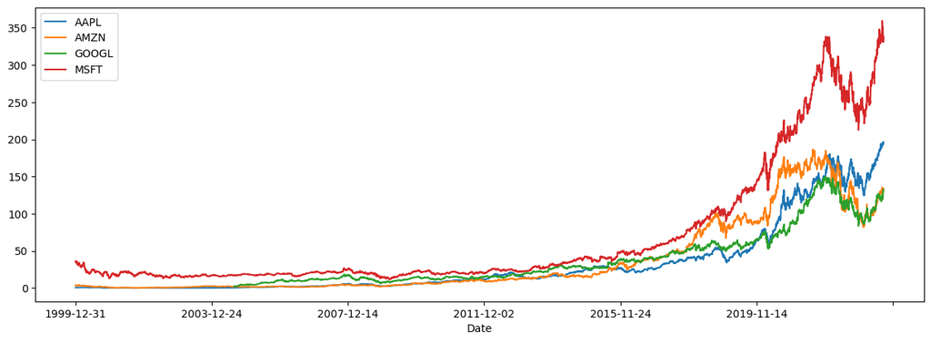

```python
# Obtain daily historical data from each company
display(companies.get_historical_data().tail(10))

# Obtain yearly historical data from each company
display(companies.get_historical_data(period="yearly"))

# Plot the Adjusted Close Prices
companies.get_historical_data()["Adj Close"].plot(figsize=(15, 5))
```

```python
# Obtain the balance sheets from each company
companies.get_balance_sheet_statement()
```

|  | date | 2000 | 2001 | 2002 | 2003 | 2004 | 2005 | 2006 | 2007 | 2008 | 2009 | ... | 2014 | 2015 | 2016 | 2017 | 2018 | 2019 | 2020 | 2021 | 2022 | 2023 |
| --- | --- | --- | --- | --- | --- | --- | --- | --- | --- | --- | --- | --- | --- | --- | --- | --- | --- | --- | --- | --- | --- | --- |
| AAPL | Cash and Cash Equivalents | 1.191000e+09 | 2.310000e+09 | 2.252000e+09 | 3.396000e+09 | 2.969000e+09 | 3.491000e+09 | 6.392000e+09 | 9.352000e+09 | 1.187500e+10 | 5.263000e+09 | ... | 1.384400e+10 | 2.112000e+10 | 2.048400e+10 | 2.028900e+10 | 2.591300e+10 | 4.884400e+10 | 3.801600e+10 | 3.494000e+10 | 2.364600e+10 | NaN |
|  | Short Term Investments | 2.836000e+09 | 2.026000e+09 | 2.085000e+09 | 1.170000e+09 | 2.495000e+09 | 4.770000e+09 | 3.718000e+09 | 6.034000e+09 | 1.261500e+10 | 1.820100e+10 | ... | 1.123300e+10 | 2.048100e+10 | 4.667100e+10 | 5.389200e+10 | 4.038800e+10 | 5.171300e+10 | 5.292700e+10 | 2.769900e+10 | 2.465800e+10 | NaN |
|  | Cash and Short Term Investments | 4.027000e+09 | 4.336000e+09 | 4.337000e+09 | 4.566000e+09 | 5.464000e+09 | 8.261000e+09 | 1.011000e+10 | 1.538600e+10 | 2.449000e+10 | 2.346400e+10 | ... | 2.507700e+10 | 4.160100e+10 | 6.715500e+10 | 7.418100e+10 | 6.630100e+10 | 1.005570e+11 | 9.094300e+10 | 6.263900e+10 | 4.830400e+10 | NaN |
|  | Accounts Receivable | 9.530000e+08 | 4.660000e+08 | 5.650000e+08 | 9.500000e+08 | 1.050000e+09 | 1.312000e+09 | 2.845000e+09 | 4.029000e+09 | 2.422000e+09 | 3.361000e+09 | ... | 2.721900e+10 | 3.034300e+10 | 2.929900e+10 | 3.567300e+10 | 4.899500e+10 | 4.580400e+10 | 3.744500e+10 | 5.150600e+10 | 6.093200e+10 | NaN |
|  | Inventory | 3.300000e+07 | 1.100000e+07 | 4.500000e+07 | 5.600000e+07 | 1.010000e+08 | 1.650000e+08 | 2.700000e+08 | 3.460000e+08 | 5.090000e+08 | 4.550000e+08 | ... | 2.111000e+09 | 2.349000e+09 | 2.132000e+09 | 4.855000e+09 | 3.956000e+09 | 4.106000e+09 | 4.061000e+09 | 6.580000e+09 | 4.946000e+09 | NaN |
| ... | ... | ... | ... | ... | ... | ... | ... | ... | ... | ... | ... | ... | ... | ... | ... | ... | ... | ... | ... | ... | ... | ... |
| MSFT | Minority Interest | 0.000000e+00 | 0.000000e+00 | 0.000000e+00 | 0.000000e+00 | 0.000000e+00 | 0.000000e+00 | 0.000000e+00 | 0.000000e+00 | 0.000000e+00 | 0.000000e+00 | ... | 0.000000e+00 | 0.000000e+00 | 0.000000e+00 | 0.000000e+00 | 0.000000e+00 | 0.000000e+00 | 0.000000e+00 | 0.000000e+00 | 0.000000e+00 | 0.000000e+00 |
|  | Total Liabilities and Equity | 5.215000e+10 | 5.925700e+10 | 6.764600e+10 | 7.957100e+10 | 9.238900e+10 | 7.081500e+10 | 6.959700e+10 | 6.317100e+10 | 7.279300e+10 | 7.788800e+10 | ... | 1.723840e+11 | 1.762230e+11 | 1.936940e+11 | 2.410860e+11 | 2.588480e+11 | 2.865560e+11 | 3.013110e+11 | 3.337790e+11 | 3.648400e+11 | 4.119760e+11 |
|  | Total Investments | 0.000000e+00 | 0.000000e+00 | 0.000000e+00 | 0.000000e+00 | 0.000000e+00 | 0.000000e+00 | 0.000000e+00 | 0.000000e+00 | 1.991100e+10 | 3.030400e+10 | ... | 9.163700e+10 | 1.029840e+11 | 1.171610e+11 | 1.313410e+11 | 1.236840e+11 | 1.251120e+11 | 1.259160e+11 | 1.220940e+11 | 9.770900e+10 | 8.643700e+10 |
|  | Total Debt | 0.000000e+00 | 0.000000e+00 | 0.000000e+00 | 0.000000e+00 | 0.000000e+00 | 0.000000e+00 | 0.000000e+00 | 0.000000e+00 | 0.000000e+00 | 5.746000e+09 | ... | 2.264500e+10 | 3.529200e+10 | 5.368700e+10 | 8.619400e+10 | 8.180800e+10 | 7.836600e+10 | 7.099800e+10 | 6.777500e+10 | 6.127000e+10 | 5.996500e+10 |
|  | Net Debt | -4.846000e+09 | -3.922000e+09 | -3.016000e+09 | -6.438000e+09 | -1.598200e+10 | -4.851000e+09 | -6.714000e+09 | -6.111000e+09 | -1.033900e+10 | -3.300000e+08 | ... | 1.397600e+10 | 2.969700e+10 | 4.717700e+10 | 7.853100e+10 | 6.986200e+10 | 6.701000e+10 | 5.742200e+10 | 5.355100e+10 | 4.733900e+10 | 2.526100e+10 |

172 rows × 24 columns

```python
# Obtain the income statements from each company
companies.get_income_statement()
```

|  | date | 2000 | 2001 | 2002 | 2003 | 2004 | 2005 | 2006 | 2007 | 2008 | 2009 | ... | 2014 | 2015 | 2016 | 2017 | 2018 | 2019 | 2020 | 2021 | 2022 | 2023 |
| --- | --- | --- | --- | --- | --- | --- | --- | --- | --- | --- | --- | --- | --- | --- | --- | --- | --- | --- | --- | --- | --- | --- |
| AAPL | Revenue | 7.983000e+09 | 5.363000e+09 | 5.742000e+09 | 6.207000e+09 | 8.279000e+09 | 1.393100e+10 | 1.931500e+10 | 2.400600e+10 | 3.247900e+10 | 3.653700e+10 | ... | 1.827950e+11 | 2.337150e+11 | 2.156390e+11 | 2.292340e+11 | 2.655950e+11 | 2.601740e+11 | 2.745150e+11 | 3.658170e+11 | 3.943280e+11 | NaN |
|  | Cost of Goods Sold | 5.817000e+09 | 4.128000e+09 | 4.139000e+09 | 4.499000e+09 | 6.020000e+09 | 9.888000e+09 | 1.371700e+10 | 1.585200e+10 | 2.133400e+10 | 2.339700e+10 | ... | 1.122580e+11 | 1.400890e+11 | 1.313760e+11 | 1.410480e+11 | 1.637560e+11 | 1.617820e+11 | 1.695590e+11 | 2.129810e+11 | 2.235460e+11 | NaN |
|  | Gross Profit | 2.166000e+09 | 1.235000e+09 | 1.603000e+09 | 1.708000e+09 | 2.259000e+09 | 4.043000e+09 | 5.598000e+09 | 8.154000e+09 | 1.114500e+10 | 1.314000e+10 | ... | 7.053700e+10 | 9.362600e+10 | 8.426300e+10 | 8.818600e+10 | 1.018390e+11 | 9.839200e+10 | 1.049560e+11 | 1.528360e+11 | 1.707820e+11 | NaN |
|  | Gross Profit Ratio | 2.713266e-01 | 2.302816e-01 | 2.791710e-01 | 2.751732e-01 | 2.728590e-01 | 2.902161e-01 | 2.898266e-01 | 3.396651e-01 | 3.431448e-01 | 3.596354e-01 | ... | 3.858804e-01 | 4.005990e-01 | 3.907596e-01 | 3.846986e-01 | 3.834372e-01 | 3.781777e-01 | 3.823325e-01 | 4.177936e-01 | 4.330963e-01 | NaN |
|  | Research and Development Expenses | 3.800000e+08 | 4.410000e+08 | 4.470000e+08 | 4.710000e+08 | 4.890000e+08 | 5.340000e+08 | 7.120000e+08 | 7.820000e+08 | 1.109000e+09 | 1.333000e+09 | ... | 6.041000e+09 | 8.067000e+09 | 1.004500e+10 | 1.158100e+10 | 1.423600e+10 | 1.621700e+10 | 1.875200e+10 | 2.191400e+10 | 2.625100e+10 | NaN |
| ... | ... | ... | ... | ... | ... | ... | ... | ... | ... | ... | ... | ... | ... | ... | ... | ... | ... | ... | ... | ... | ... | ... |
| MSFT | Net Income Ratio | 4.103938e-01 | 2.904016e-01 | 2.760092e-01 | 3.104670e-01 | 2.217456e-01 | 3.079823e-01 | 2.845174e-01 | 2.751262e-01 | 2.926349e-01 | 2.493112e-01 | ... | 2.542121e-01 | 1.302949e-01 | 1.968823e-01 | 2.357310e-01 | 1.501540e-01 | 3.118171e-01 | 3.096249e-01 | 3.645174e-01 | 3.668634e-01 | 3.414624e-01 |
|  | EPS | 9.050000e-01 | 6.900000e-01 | 7.250000e-01 | 9.300000e-01 | 7.600000e-01 | 1.130000e+00 | 1.210000e+00 | 1.440000e+00 | 1.900000e+00 | 1.630000e+00 | ... | 2.660000e+00 | 1.490000e+00 | 2.120000e+00 | 2.740000e+00 | 2.150000e+00 | 5.110000e+00 | 5.820000e+00 | 8.120000e+00 | 9.700000e+00 | 9.720000e+00 |
|  | EPS Diluted | 8.500000e-01 | 6.600000e-01 | 7.050000e-01 | 9.200000e-01 | 7.500000e-01 | 1.120000e+00 | 1.200000e+00 | 1.420000e+00 | 1.870000e+00 | 1.620000e+00 | ... | 2.630000e+00 | 1.480000e+00 | 2.100000e+00 | 2.710000e+00 | 2.130000e+00 | 5.060000e+00 | 5.760000e+00 | 8.050000e+00 | 9.650000e+00 | 9.680000e+00 |
|  | Weighted Average Shares | 1.037800e+10 | 1.068200e+10 | 1.081200e+10 | 1.072300e+10 | 1.080300e+10 | 1.083900e+10 | 1.043800e+10 | 9.742000e+09 | 9.328000e+09 | 8.945000e+09 | ... | 8.299000e+09 | 8.177000e+09 | 7.925000e+09 | 7.746000e+09 | 7.700000e+09 | 7.673000e+09 | 7.610000e+09 | 7.547000e+09 | 7.496000e+09 | 7.446000e+09 |
|  | Weighted Average Shares Diluted | 1.107200e+10 | 1.114800e+10 | 1.110600e+10 | 1.088200e+10 | 1.089400e+10 | 1.090600e+10 | 1.053100e+10 | 9.886000e+09 | 9.470000e+09 | 8.996000e+09 | ... | 8.399000e+09 | 8.254000e+09 | 8.013000e+09 | 7.832000e+09 | 7.794000e+09 | 7.753000e+09 | 7.683000e+09 | 7.608000e+09 | 7.540000e+09 | 7.472000e+09 |

112 rows × 24 columns

```python
# Obtain the cash flow statements from each company
companies.get_cash_flow_statement()
```

|  | date | 2000 | 2001 | 2002 | 2003 | 2004 | 2005 | 2006 | 2007 | 2008 | 2009 | ... | 2014 | 2015 | 2016 | 2017 | 2018 | 2019 | 2020 | 2021 | 2022 | 2023 |
| --- | --- | --- | --- | --- | --- | --- | --- | --- | --- | --- | --- | --- | --- | --- | --- | --- | --- | --- | --- | --- | --- | --- |
| AAPL | Net Income | 7.860000e+08 | -3.700000e+07 | 6.500000e+07 | 6.800000e+07 | 2.760000e+08 | 1.335000e+09 | 1.989000e+09 | 3.496000e+09 | 4.834000e+09 | 5.704000e+09 | ... | 3.951000e+10 | 5.339400e+10 | 4.568700e+10 | 4.835100e+10 | 5.953100e+10 | 5.525600e+10 | 5.741100e+10 | 9.468000e+10 | 9.980300e+10 | NaN |
|  | Depreciation and Amortization | 8.400000e+07 | 1.020000e+08 | 1.180000e+08 | 1.130000e+08 | 1.500000e+08 | 1.790000e+08 | 2.250000e+08 | 3.170000e+08 | 4.730000e+08 | 7.030000e+08 | ... | 7.946000e+09 | 1.125700e+10 | 1.050500e+10 | 1.015700e+10 | 1.090300e+10 | 1.254700e+10 | 1.105600e+10 | 1.128400e+10 | 1.110400e+10 | NaN |
|  | Deferred Income Tax | 1.630000e+08 | -3.600000e+07 | -3.400000e+07 | -1.100000e+07 | 2.000000e+07 | 5.050000e+08 | 5.300000e+07 | 7.800000e+07 | -3.680000e+08 | -5.190000e+08 | ... | 2.347000e+09 | 1.382000e+09 | 4.938000e+09 | 5.966000e+09 | -3.259000e+10 | -3.400000e+08 | -2.150000e+08 | -4.774000e+09 | 8.950000e+08 | NaN |
|  | Stock Based Compensation | 0.000000e+00 | 0.000000e+00 | 0.000000e+00 | 1.600000e+07 | 3.300000e+07 | 4.200000e+07 | 1.630000e+08 | 2.420000e+08 | 5.160000e+08 | 7.100000e+08 | ... | 2.863000e+09 | 3.586000e+09 | 4.210000e+09 | 4.840000e+09 | 5.340000e+09 | 6.068000e+09 | 6.829000e+09 | 7.906000e+09 | 9.038000e+09 | NaN |
|  | Change in Working Capital | 1.570000e+08 | 2.110000e+08 | -1.030000e+08 | 1.260000e+08 | 4.480000e+08 | 4.650000e+08 | -2.210000e+08 | 1.325000e+09 | 4.119000e+09 | 3.535000e+09 | ... | 7.047000e+09 | 1.164700e+10 | 4.840000e+08 | -5.550000e+09 | 3.469400e+10 | -3.488000e+09 | 5.690000e+09 | -4.911000e+09 | 1.200000e+09 | NaN |
| ... | ... | ... | ... | ... | ... | ... | ... | ... | ... | ... | ... | ... | ... | ... | ... | ... | ... | ... | ... | ... | ... | ... |
| MSFT | Cash End of Period | 4.846000e+09 | 3.922000e+09 | 3.016000e+09 | 6.438000e+09 | 1.598200e+10 | 4.851000e+09 | 6.714000e+09 | 6.111000e+09 | 1.033900e+10 | 6.076000e+09 | ... | 8.669000e+09 | 5.595000e+09 | 6.510000e+09 | 7.663000e+09 | 1.194600e+10 | 1.135600e+10 | 1.357600e+10 | 1.422400e+10 | 1.393100e+10 | 3.470400e+10 |
|  | Cash Beginning of Period | 4.975000e+09 | 4.846000e+09 | 3.922000e+09 | 3.016000e+09 | 6.438000e+09 | 1.430400e+10 | 4.851000e+09 | 6.714000e+09 | 6.111000e+09 | 1.033900e+10 | ... | 3.804000e+09 | 8.669000e+09 | 5.595000e+09 | 6.510000e+09 | 7.663000e+09 | 1.194600e+10 | 1.135600e+10 | 1.357600e+10 | 1.422400e+10 | 1.393100e+10 |
|  | Operating Cash Flow | 1.396100e+10 | 1.342200e+10 | 1.450900e+10 | 1.579700e+10 | 1.462600e+10 | 1.660500e+10 | 1.440400e+10 | 1.779600e+10 | 2.161200e+10 | 1.903700e+10 | ... | 3.223100e+10 | 2.908000e+10 | 3.332500e+10 | 3.950700e+10 | 4.388400e+10 | 5.218500e+10 | 6.067500e+10 | 7.674000e+10 | 8.903500e+10 | 8.758200e+10 |
|  | Capital Expenditure | -8.790000e+08 | -1.103000e+09 | -7.700000e+08 | -8.910000e+08 | -1.109000e+09 | -8.120000e+08 | -1.578000e+09 | -2.264000e+09 | -3.182000e+09 | -3.119000e+09 | ... | -5.485000e+09 | -5.944000e+09 | -8.343000e+09 | -8.129000e+09 | -1.163200e+10 | -1.392500e+10 | -1.544100e+10 | -2.062200e+10 | -2.388600e+10 | -2.810700e+10 |
|  | Free Cash Flow | 1.308200e+10 | 1.231900e+10 | 1.373900e+10 | 1.490600e+10 | 1.351700e+10 | 1.579300e+10 | 1.282600e+10 | 1.553200e+10 | 1.843000e+10 | 1.591800e+10 | ... | 2.674600e+10 | 2.313600e+10 | 2.498200e+10 | 3.137800e+10 | 3.225200e+10 | 3.826000e+10 | 4.523400e+10 | 5.611800e+10 | 6.514900e+10 | 5.947500e+10 |

120 rows × 24 columns

With this structure, it is easy to select and plot specific companies, financial statement items and/or years. See some examples below.

| date | 2000 | 2001 | 2002 | 2003 | 2004 | 2005 | 2006 | 2007 | 2008 | 2009 | ... | 2014 | 2015 | 2016 | 2017 | 2018 | 2019 | 2020 | 2021 | 2022 | 2023 |
| --- | --- | --- | --- | --- | --- | --- | --- | --- | --- | --- | --- | --- | --- | --- | --- | --- | --- | --- | --- | --- | --- |
| Cash and Cash Equivalents | 8.224350e+08 | 540282000.0 | 7.382540e+08 | 1.102273e+09 | 1.302600e+09 | 1.013000e+09 | 1.022000e+09 | 2.539000e+09 | 2.769000e+09 | 3.444000e+09 | ... | 1.455700e+10 | 1.589000e+10 | 1.933400e+10 | 2.052200e+10 | 3.175000e+10 | 3.609200e+10 | 4.212200e+10 | 3.622000e+10 | 5.388800e+10 | NaN |
| Short Term Investments | 2.780870e+08 | 456303000.0 | 5.627150e+08 | 2.925500e+08 | 4.765990e+08 | 9.870000e+08 | 9.970000e+08 | 5.730000e+08 | 9.580000e+08 | 2.922000e+09 | ... | 2.859000e+09 | 3.918000e+09 | 6.647000e+09 | 1.046400e+10 | 9.500000e+09 | 1.892900e+10 | 4.227400e+10 | 5.982900e+10 | 1.613800e+10 | NaN |
| Cash and Short Term Investments | 1.100522e+09 | 996585000.0 | 1.300969e+09 | 1.394823e+09 | 1.779199e+09 | 2.000000e+09 | 2.019000e+09 | 3.112000e+09 | 3.727000e+09 | 6.366000e+09 | ... | 1.741600e+10 | 1.980800e+10 | 2.598100e+10 | 3.098600e+10 | 4.125000e+10 | 5.502100e+10 | 8.439600e+10 | 9.604900e+10 | 7.002600e+10 | NaN |
| Accounts Receivable | 0.000000e+00 | 0.0 | 1.122820e+08 | 1.320690e+08 | 1.991000e+08 | 2.740000e+08 | 3.990000e+08 | 7.050000e+08 | 8.270000e+08 | 9.880000e+08 | ... | 5.612000e+09 | 6.423000e+09 | 8.339000e+09 | 1.316400e+10 | 1.667700e+10 | 2.081600e+10 | 2.454200e+10 | 3.289100e+10 | 4.236000e+10 | NaN |
| Inventory | 1.745630e+08 | 143722000.0 | 2.024250e+08 | 2.939170e+08 | 4.797090e+08 | 5.660000e+08 | 8.770000e+08 | 1.200000e+09 | 1.399000e+09 | 2.171000e+09 | ... | 8.299000e+09 | 1.024300e+10 | 1.146100e+10 | 1.604700e+10 | 1.717400e+10 | 2.049700e+10 | 2.379500e+10 | 3.264000e+10 | 3.440500e+10 | NaN |

5 rows × 24 columns

| date | 2000 | 2001 | 2002 | 2003 | 2004 | 2005 | 2006 | 2007 | 2008 | 2009 | ... | 2014 | 2015 | 2016 | 2017 | 2018 | 2019 | 2020 | 2021 | 2022 | 2023 |
| --- | --- | --- | --- | --- | --- | --- | --- | --- | --- | --- | --- | --- | --- | --- | --- | --- | --- | --- | --- | --- | --- |
| AAPL | 9.530000e+08 | 4.660000e+08 | 5.650000e+08 | 9.500000e+08 | 1.050000e+09 | 1.312000e+09 | 2.845000e+09 | 4.029000e+09 | 2.422000e+09 | 3.361000e+09 | ... | 2.721900e+10 | 3.034300e+10 | 2.929900e+10 | 3.567300e+10 | 4.899500e+10 | 4.580400e+10 | 3.744500e+10 | 5.150600e+10 | 6.093200e+10 | NaN |
| AMZN | 0.000000e+00 | 0.000000e+00 | 1.122820e+08 | 1.320690e+08 | 1.991000e+08 | 2.740000e+08 | 3.990000e+08 | 7.050000e+08 | 8.270000e+08 | 9.880000e+08 | ... | 5.612000e+09 | 6.423000e+09 | 8.339000e+09 | 1.316400e+10 | 1.667700e+10 | 2.081600e+10 | 2.454200e+10 | 3.289100e+10 | 4.236000e+10 | NaN |
| GOOGL | 0.000000e+00 | NaN | 6.199400e+07 | 1.546900e+08 | 3.823450e+08 | 6.879760e+08 | 1.322340e+09 | 2.307774e+09 | 2.642192e+09 | 3.201715e+09 | ... | 1.155600e+10 | 1.390900e+10 | 1.423200e+10 | 1.870500e+10 | 2.119300e+10 | 2.749200e+10 | 3.138400e+10 | 4.027000e+10 | 4.025800e+10 | NaN |
| MSFT | 3.250000e+09 | 3.671000e+09 | 5.129000e+09 | 5.196000e+09 | 5.890000e+09 | 7.180000e+09 | 9.316000e+09 | 1.133800e+10 | 1.358900e+10 | 1.119200e+10 | ... | 1.954400e+10 | 1.790800e+10 | 1.827700e+10 | 1.979200e+10 | 2.648100e+10 | 2.952400e+10 | 3.201100e+10 | 3.804300e+10 | 4.426100e+10 | 4.868800e+10 |

4 rows × 24 columns

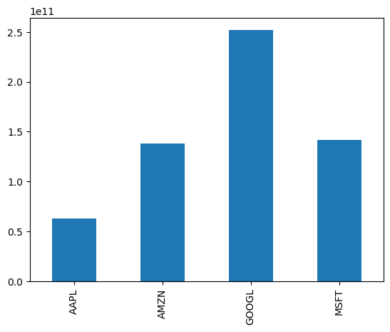

```python
# Save to a variable for easier access
balance_sheet = companies.get_balance_sheet_statement()

# Show only the balance sheet statement for Amazon (purposely cut off to keep it compact)
display(balance_sheet.loc["AMZN"].head())

# Show the growth of the Accounts Receivable for each company
display(balance_sheet.loc[:, "Accounts Receivable", :])

# Plot the value of Total Shareholder Equity for each company in 2021
balance_sheet.loc[:, "Total Shareholder Equity", :]["2021"].plot(kind="bar")
```

There are several other functionalities within the `Toolkit` class which includes observing company profiles, company quotes, enterprise values and ratings. For example, after initialization you can call the functionality `get_profile`.

```python
companies.get_profile()
```

|  | AAPL | MSFT | GOOGL | AMZN |
| --- | --- | --- | --- | --- |
| symbol | AAPL | MSFT | GOOGL | AMZN |
| price | 196.45 | 335.92 | 132.72 | 133.68 |
| beta | 1.292349 | 0.91086 | 1.052595 | 1.257855 |
| volAvg | 56926808 | 28866006 | 34799512 | 59553403 |
| mktCap | 3089903196723 | 2497729730929 | 1687309229619 | 1371610289111 |
| lastDiv | 0.96 | 2.72 | 0 | 0.2 |
| range | 124.17-198.23 | 213.43-366.78 | 83.34-133.74 | 81.43-146.57 |
| changes | 0.62 | -2.45 | 0.14 | 1.47 |
| companyName | Apple Inc. | Microsoft Corporation | Alphabet Inc. | Amazon.com, Inc. |
| currency | USD | USD | USD | USD |
| cik | 320193 | 789019 | 1652044 | 1018724 |
| isin | US0378331005 | US5949181045 | US02079K3059 | US0231351067 |
| cusip | 37833100 | 594918104 | 02079K305 | 23135106 |
| exchange | NASDAQ Global Select | NASDAQ Global Select | NASDAQ Global Select | NASDAQ Global Select |
| exchangeShortName | NASDAQ | NASDAQ | NASDAQ | NASDAQ |
| industry | Consumer Electronics | Software—Infrastructure | Internet Content & Information | Internet Retail |
| website | https://www.apple.com | https://www.microsoft.com | https://www.abc.xyz | https://www.amazon.com |
| description | Apple Inc. designs, manufactures, and markets ... | Microsoft Corporation develops, licenses, and ... | Alphabet Inc. provides various products and pl... | Amazon.com, Inc. engages in the retail sale of... |
| ceo | Mr. Timothy D. Cook | Mr. Satya Nadella | Mr. Sundar Pichai | Mr. Andrew R. Jassy |
| sector | Technology | Technology | Communication Services | Consumer Cyclical |
| country | US | US | US | US |
| fullTimeEmployees | 164000 | 221000 | 190711 | 1541000 |
| phone | 408 996 1010 | 425 882 8080 | 650 253 0000 | 206 266 1000 |
| address | One Apple Park Way | One Microsoft Way | 1600 Amphitheatre Parkway | 410 Terry Avenue North |
| city | Cupertino | Redmond | Mountain View | Seattle |
| state | CA | WA | CA | WA |
| zip | 95014 | 98052-6399 | 94043 | 98109-5210 |
| dcfDiff | 4.15176 | 4.56584 | 27.1372 | 61.2396 |
| dcf | 150.082 | 243.594 | 126.507 | 163.48 |
| image | https://financialmodelingprep.com/image-stock/... | https://financialmodelingprep.com/image-stock/... | https://financialmodelingprep.com/image-stock/... | https://financialmodelingprep.com/image-stock/... |
| ipoDate | 1980-12-12 | 1986-03-13 | 2004-08-19 | 1997-05-15 |
| defaultImage | False | False | False | False |
| isEtf | False | False | False | False |
| isActivelyTrading | True | True | True | True |
| isAdr | False | False | False | False |
| isFund | False | False | False | False |

# The Ratios Module

After initialization of `Toolkit`, you can get access to the Ratios module which includes over 50 different ratios. This can be done by calling the `ratios` property.

```python
ratios = companies.ratios

help(ratios)
```

```
Help on Ratios in module financetoolkit.base.ratios_controller object:

class Ratios(builtins.object)
 |  Ratios(tickers: str | list[str], historical: pandas.core.frame.DataFrame, balance: pandas.core.frame.DataFrame, income: pandas.core.frame.DataFrame, cash: pandas.core.frame.DataFrame, custom_ratios: dict | None = None)
 |  Ratios Controller Class
 |  Methods defined here:
 |  __init__(self, tickers: str | list[str], historical: pandas.core.frame.DataFrame, balance: pandas.core.frame.DataFrame, income: pandas.core.frame.DataFrame, cash: pandas.core.frame.DataFrame, custom_ratios: dict | None = None)
 |      Initialize self.  See help(type(self)) for accurate signature.
 |  collect_all_ratios(self, include_dividends: bool = False, diluted: bool = True, days: int = 365)
 |      Calculates all Ratios based on the data provided.
 |  collect_custom_ratios(self, overwrite: bool = False)
 |      Calculates all Custom Ratios based on the data provided.
 |  collect_efficiency_ratios(self, days: int = 365)
 |      Calculates all Efficiency Ratios based on the data provided.
 |  collect_liquidity_ratios(self) -> pandas.core.frame.DataFrame
 |      Calculates all Liquidity Ratios based on the data provided.
 |  collect_profitability_ratios(self) -> pandas.core.frame.DataFrame
 |      Calculates all Profitability Ratios based on the data provided.
 |  collect_solvency_ratios(self, diluted: bool = True)
 |      Calculates all Solvency Ratios based on the data provided.
 |  collect_valuation_ratios(self, include_dividends: bool = False, diluted: bool = True)
 |      Calculates all Valuation Ratios based on the data provided.
 |  get_EBIT_to_revenue = wrapper(*args, **kwargs)
 |  get_EBT_to_EBIT = wrapper(*args, **kwargs)
 |  get_accounts_payables_turnover_ratio = wrapper(*args, **kwargs)
 |  get_asset_turnover_ratio = wrapper(*args, **kwargs)
 |  get_book_value_per_share = wrapper(*args, **kwargs)
 |  get_capex_coverage_ratio = wrapper(*args, **kwargs)
 |  get_capex_dividend_coverage_ratio = wrapper(*args, **kwargs)
 |  get_capex_per_share = wrapper(*args, **kwargs)
 |  get_cash_conversion_cycle = wrapper(*args, **kwargs)
 |  get_cash_flow_coverage_ratio = wrapper(*args, **kwargs)
 |  get_cash_ratio = wrapper(*args, **kwargs)
 |  get_current_ratio = wrapper(*args, **kwargs)
 |  get_days_of_accounts_payable_outstanding = wrapper(*args, **kwargs)
 |  get_days_of_inventory_outstanding = wrapper(*args, **kwargs)
 |  get_days_of_sales_outstanding = wrapper(*args, **kwargs)
 |  get_debt_service_coverage_ratio = wrapper(*args, **kwargs)
 |  get_debt_to_assets_ratio = wrapper(*args, **kwargs)
 |  get_debt_to_equity_ratio = wrapper(*args, **kwargs)
```

[output cut: 41 more lines]

```
 |  get_return_on_equity = wrapper(*args, **kwargs)
 |  get_return_on_invested_capital = wrapper(*args, **kwargs)
 |  get_return_on_tangible_assets = wrapper(*args, **kwargs)
 |  get_revenue_per_share = wrapper(*args, **kwargs)
 |  get_sga_to_revenue_ratio = wrapper(*args, **kwargs)
 |  get_short_term_coverage_ratio = wrapper(*args, **kwargs)
 |  get_tangible_asset_value = wrapper(*args, **kwargs)
 |  get_tax_burden_ratio = wrapper(*args, **kwargs)
 |  get_working_capital = wrapper(*args, **kwargs)
 |  ----------------------------------------------------------------------
 |  Data descriptors defined here:
 |  __dict__
 |      dictionary for instance variables (if defined)
 |  __weakref__
 |      list of weak references to the object (if defined)
```

Within this ratios module, the distinction is made between `collect_` and `get_`. The former obtains a collection of ratios (e.g. all solvency ratios) whereas the latter obtains a specific ratio.

```python
ratios.collect_valuation_ratios()
```

|  |  | 2000 | 2001 | 2002 | 2003 | 2004 | 2005 | 2006 | 2007 | 2008 | 2009 | ... | 2014 | 2015 | 2016 | 2017 | 2018 | 2019 | 2020 | 2021 | 2022 | 2023 |
| --- | --- | --- | --- | --- | --- | --- | --- | --- | --- | --- | --- | --- | --- | --- | --- | --- | --- | --- | --- | --- | --- | --- |
| AAPL | Earnings per Share (EPS) | 3.895304e-02 | -1.911717e-03 | 3.208299e-03 | 3.389981e-03 | 1.272257e-02 | 5.564219e-02 | 8.094998e-02 | 1.404006e-01 | 1.913706e-01 | 2.246011e-01 | ... | 1.613269e+00 | 2.304219e+00 | 2.076576e+00 | 2.301687e+00 | 2.976485e+00 | 2.971447e+00 | 3.275348e+00 | 5.614020e+00 | 6.113200e+00 | NaN |
|  | Revenue per Share (RPS) | 3.956261e-01 | 2.770956e-01 | 2.834162e-01 | 3.049509e-01 | 3.816310e-01 | 5.806378e-01 | 7.860980e-01 | 9.640896e-01 | 1.285793e+00 | 1.438683e+00 | ... | 7.463868e+00 | 1.008598e+01 | 9.801272e+00 | 1.091239e+01 | 1.327946e+01 | 1.399112e+01 | 1.566132e+01 | 2.169100e+01 | 2.415364e+01 | NaN |
|  | Price-to-Earnings (PE) | 5.795851e+00 | -1.738688e+02 | 6.779107e+01 | 9.567723e+01 | 7.682677e+01 | 3.921894e+01 | 3.181379e+01 | 4.282559e+01 | 1.353817e+01 | 2.848040e+01 | ... | 1.535229e+01 | 1.042477e+01 | 1.301126e+01 | 1.742782e+01 | 1.275034e+01 | 2.413360e+01 | 3.991494e+01 | 3.135591e+01 | 2.119229e+01 | NaN |
|  | Earnings per Share Growth | NaN | -1.049077e+00 | -2.678229e+00 | 5.662893e-02 | 2.752992e+00 | 3.373502e+00 | 4.548309e-01 | 7.344119e-01 | 3.630323e-01 | 1.736447e-01 | ... | 1.362851e-01 | 4.282923e-01 | -9.879414e-02 | 1.084049e-01 | 2.931756e-01 | -1.692536e-03 | 1.022736e-01 | 7.140226e-01 | 8.891663e-02 | 0.000000e+00 |
|  | Price-to-Earnings-Growth (PEG) | 1.487907e+02 | 9.094903e+04 | 2.112991e+04 | 2.822353e+04 | 6.038619e+03 | 7.048418e+02 | 3.930056e+02 | 3.050242e+02 | 7.074321e+01 | 1.268044e+02 | ... | 9.516263e+00 | 4.524209e+00 | 6.265727e+00 | 7.571759e+00 | 4.283690e+00 | 8.121835e+00 | 1.218647e+01 | 5.585287e+00 | 3.466644e+00 | NaN |
| ... | ... | ... | ... | ... | ... | ... | ... | ... | ... | ... | ... | ... | ... | ... | ... | ... | ... | ... | ... | ... | ... | ... |
| MSFT | EV-to-EBIT | 1.013241e+01 | 2.026610e+01 | 1.526173e+01 | 1.226528e+01 | 1.544559e+01 | 1.189626e+01 | 1.204557e+01 | 1.248942e+01 | 5.318772e+00 | 1.051949e+01 | ... | 1.241817e+01 | 2.272577e+01 | 2.399246e+01 | 2.784610e+01 | 2.103498e+01 | 2.695673e+01 | 3.107287e+01 | 3.508158e+01 | 2.153359e+01 | 2.838682e+01 |
|  | EV-to-EBITDA | 1.228158e+01 | 1.704639e+01 | 1.352227e+01 | 1.232386e+01 | 1.843193e+01 | 1.283154e+01 | 1.266050e+01 | 1.257513e+01 | 5.159737e+00 | 9.095173e+00 | ... | 1.070295e+01 | 1.817459e+01 | 1.879189e+01 | 2.271359e+01 | 1.819807e+01 | 2.287826e+01 | 2.628683e+01 | 3.157609e+01 | 1.887851e+01 | 2.476222e+01 |
|  | EV-to-Operating-Cash-Flow | 1.036030e+01 | 1.683557e+01 | 1.211030e+01 | 1.143372e+01 | 1.287942e+01 | 1.191274e+01 | 1.527188e+01 | 1.410709e+01 | 5.860690e+00 | 1.095272e+01 | ... | 1.094868e+01 | 1.507341e+01 | 1.511471e+01 | 1.788249e+01 | 1.879315e+01 | 2.395499e+01 | 2.848769e+01 | 3.357664e+01 | 2.074611e+01 | 2.894722e+01 |
|  | Tangible Asset Value | 4.136800e+10 | 4.728900e+10 | 5.218000e+10 | 6.102000e+10 | 7.482500e+10 | 4.811500e+10 | 3.623800e+10 | 2.633700e+10 | 2.417800e+10 | 2.705500e+10 | ... | 6.965700e+10 | 6.314400e+10 | 5.412500e+10 | 3.727200e+10 | 4.703500e+10 | 6.030400e+10 | 7.495300e+10 | 9.227700e+10 | 9.901800e+10 | 1.383370e+11 |
|  | Net Current Asset Value | 2.055300e+10 | 2.850500e+10 | 3.583200e+10 | 4.499900e+10 | 5.559700e+10 | 3.186000e+10 | 2.656800e+10 | 1.641400e+10 | 1.335600e+10 | 2.224600e+10 | ... | 6.862100e+10 | 7.485400e+10 | 8.030300e+10 | 9.532400e+10 | 1.111740e+11 | 1.061320e+11 | 1.096050e+11 | 9.574900e+10 | 7.460200e+10 | 8.010800e+10 |

88 rows × 24 columns

```python
ratios.get_effective_tax_rate()
```

| date | 2000 | 2001 | 2002 | 2003 | 2004 | 2005 | 2006 | 2007 | 2008 | 2009 | ... | 2014 | 2015 | 2016 | 2017 | 2018 | 2019 | 2020 | 2021 | 2022 | 2023 |
| --- | --- | --- | --- | --- | --- | --- | --- | --- | --- | --- | --- | --- | --- | --- | --- | --- | --- | --- | --- | --- | --- |
| AAPL | 0.280220 | 0.288462 | 0.252874 | 0.260870 | 0.279373 | 0.264463 | 0.294180 | 0.301917 | 0.298912 | 0.285571 | ... | 0.261261 | 0.263683 | 0.255573 | 0.245565 | 0.183422 | 0.159438 | 0.144282 | 0.133023 | 0.162045 | NaN |
| AMZN | -0.000000 | -0.000000 | -0.000000 | 0.000000 | -0.653556 | 0.221963 | 0.496021 | 0.278788 | 0.274140 | 0.217916 | ... | -1.504505 | 0.605867 | 0.366136 | 0.202049 | 0.106296 | 0.169863 | 0.118413 | 0.125580 | 0.541947 | NaN |
| GOOGL | -0.000000 | 0.306218 | 0.461071 | 0.695235 | 0.386192 | 0.315771 | 0.232756 | 0.259123 | 0.277904 | 0.222014 | ... | 0.193001 | 0.168083 | 0.193458 | 0.534365 | 0.119640 | 0.133300 | 0.162493 | 0.162023 | 0.159208 | NaN |
| MSFT | 0.340035 | 0.330065 | 0.319986 | 0.321404 | 0.330272 | 0.263050 | 0.310097 | 0.300284 | 0.257538 | 0.264971 | ... | 0.206542 | 0.341168 | 0.149511 | 0.084021 | 0.545676 | 0.101813 | 0.165077 | 0.138266 | 0.131134 | 0.189786 |

4 rows × 24 columns

Some of these ratios also include optional fields depending on whether there is room for different methods of calculation. E.g. whether you'd like to have the diluted average shares included in the calculation.

```python
ratios.collect_solvency_ratios(diluted=False)
```

|  | date | 2000 | 2001 | 2002 | 2003 | 2004 | 2005 | 2006 | 2007 | 2008 | 2009 | ... | 2014 | 2015 | 2016 | 2017 | 2018 | 2019 | 2020 | 2021 | 2022 | 2023 |
| --- | --- | --- | --- | --- | --- | --- | --- | --- | --- | --- | --- | --- | --- | --- | --- | --- | --- | --- | --- | --- | --- | --- |
| AAPL | Debt-to-Assets Ratio | 0.044098 | 0.052649 | 0.050175 | 0.044607 | 0.000000 | 0.000000 | 0.000000 | 0.000000 | 0.000000 | 0.000000 | ... | 0.152239 | 0.221916 | 0.270550 | 0.308218 | 0.313030 | 0.319178 | 0.347145 | 0.355323 | 0.340375 | NaN |
|  | Debt-to-Equity Ratio | 0.073046 | 0.080867 | 0.077167 | 0.071987 | 0.000000 | 0.000000 | 0.000000 | 0.000000 | 0.000000 | 0.000000 | ... | 0.316414 | 0.540086 | 0.678617 | 0.862981 | 1.068467 | 1.194048 | 1.720810 | 1.976843 | 2.369533 | NaN |
|  | Debt Service Coverage Ratio | 0.432488 | -0.226614 | 0.101327 | 0.037760 | 0.121642 | 0.473594 | 0.379076 | 0.474137 | 0.445288 | 0.397158 | ... | 0.827497 | 0.883637 | 0.791927 | 0.608487 | 0.606661 | 0.604722 | 0.628966 | 0.868251 | 0.775656 | NaN |
|  | Equity Multiplier | NaN | 1.597608 | 1.536993 | 1.576461 | 1.598559 | 1.562829 | 1.647908 | 1.735683 | 1.825516 | 1.911977 | ... | 1.866637 | 2.262077 | 2.472355 | 2.657322 | 3.072398 | 3.563342 | 4.250894 | 5.254966 | 6.186222 | NaN |
|  | Free Cash Flow Yield | 0.175217 | -0.007306 | -0.019658 | 0.019083 | 0.037267 | 0.046055 | 0.025680 | 0.030805 | 0.131300 | 0.055931 | ... | 0.082767 | 0.126224 | 0.088414 | 0.060687 | 0.085239 | 0.044463 | 0.032340 | 0.031617 | 0.053047 | NaN |
|  | Net-Debt to EBITDA Ratio | -0.968478 | 8.235537 | -6.769231 | -15.306931 | -6.237395 | -1.908693 | -2.386856 | -1.978840 | -1.759781 | -0.629470 | ... | 0.354861 | 0.525440 | 0.910718 | 1.334121 | 1.082750 | 0.774128 | 0.962195 | 0.746708 | 0.738641 | NaN |
|  | Cash Flow Coverage Ratio | 0.175217 | -0.007306 | -0.019658 | 0.019083 | 0.037267 | 0.046055 | 0.025680 | 0.030805 | 0.131300 | 0.055931 | ... | 0.082767 | 0.126224 | 0.088414 | 0.060687 | 0.085239 | 0.044463 | 0.032340 | 0.031617 | 0.053047 | NaN |
|  | CAPEX Coverage Ratio | -7.719626 | -0.797414 | -0.511494 | -1.762195 | -5.306818 | -9.750000 | -3.378995 | -5.547667 | -8.003336 | -8.375103 | ... | -6.085091 | -7.073990 | -4.858577 | -4.970535 | -5.816420 | -6.611815 | -11.037625 | -9.385476 | -11.407452 | NaN |
|  | Dividend CAPEX Coverage Ratio | -7.719626 | -0.797414 | -0.511494 | -1.762195 | -5.306818 | -9.750000 | -3.378995 | -5.547667 | -8.003336 | -8.375103 | ... | -2.851760 | -3.525793 | -2.561444 | -2.487795 | -2.865273 | -2.819168 | -3.771576 | -4.071619 | -4.781048 | NaN |
| AMZN | Debt-to-Assets Ratio | 1.004155 | 1.325840 | 1.150807 | 0.901769 | 0.571863 | 0.411526 | 0.290397 | 0.207247 | 0.056291 | 0.018244 | ... | 0.229135 | 0.216720 | 0.182406 | 0.288828 | 0.244620 | 0.280602 | 0.262734 | 0.276769 | 0.302843 | NaN |
|  | Debt-to-Equity Ratio | -2.216634 | -1.507726 | -1.693228 | -1.881712 | -8.176101 | 6.182927 | 2.939675 | 1.122807 | 0.175150 | 0.047936 | ... | 1.162741 | 1.059698 | 0.788851 | 1.368725 | 0.913615 | 1.018450 | 0.903484 | 0.841947 | 0.959430 | NaN |
|  | Debt Service Coverage Ratio | -0.886071 | -0.447418 | 0.060156 | 0.216009 | 0.271800 | 0.223950 | 0.153633 | 0.176360 | 0.177413 | 0.153313 | ... | 0.006337 | 0.065872 | 0.095536 | 0.070936 | 0.181617 | 0.165592 | 0.181184 | 0.280882 | -0.022968 | NaN |
|  | Equity Multiplier | NaN | -1.567230 | -1.299047 | -1.738225 | -4.282802 | 369.604982 | 11.903988 | 6.663391 | 3.825019 | 2.790642 | ... | 4.620686 | 4.971979 | 4.556185 | 4.568924 | 4.125263 | 3.672945 | 3.514917 | 3.202017 | 3.106793 | NaN |
|  | Free Cash Flow Yield | -0.048567 | -0.043165 | 0.018906 | 0.016629 | 0.026555 | 0.027232 | 0.029606 | 0.030867 | 0.062882 | 0.050131 | ... | 0.013593 | 0.023226 | 0.027307 | 0.011542 | 0.023646 | 0.023721 | 0.015919 | -0.008728 | -0.019738 | NaN |
|  | Net-Debt to EBITDA Ratio | -2.887822 | -11.130894 | 10.221292 | 2.428690 | 1.075465 | 0.918626 | 0.412458 | -1.326304 | -2.038087 | -2.118115 | ... | -0.419984 | -0.200493 | -0.334986 | 1.116786 | 0.289496 | 0.725626 | 0.827532 | 1.079711 | 2.248383 | NaN |
|  | Cash Flow Coverage Ratio | -0.048567 | -0.043165 | 0.018906 | 0.016629 | 0.026555 | 0.027232 | 0.029606 | 0.030867 | 0.062882 | 0.050131 | ... | 0.013593 | 0.023226 | 0.027307 | 0.011542 | 0.023646 | 0.023721 | 0.015919 | -0.008728 | -0.019738 | NaN |
|  | CAPEX Coverage Ratio | 0.967972 | 2.380358 | -4.450400 | -8.529078 | -6.356344 | -3.593137 | -3.250000 | -6.272321 | -5.096096 | -8.828418 | ... | -1.398324 | -2.597516 | -2.440701 | -1.541949 | -2.288151 | -2.284206 | -1.645840 | -0.758800 | -0.734575 | NaN |
|  | Dividend CAPEX Coverage Ratio | 0.967972 | 2.380358 | -4.450400 | -8.529078 | -6.356344 | -3.593137 | -3.250000 | -6.272321 | -5.096096 | -8.828418 | ... | -1.398324 | -2.597516 | -2.440701 | -1.541949 | -2.288151 | -2.284206 | -1.645840 | -0.758800 | -0.734575 | NaN |
| GOOGL | Debt-to-Assets Ratio | 0.000000 | NaN | 0.037861 | 0.007584 | 0.000574 | 0.000000 | 0.000000 | 0.000000 | 0.000000 | 0.000000 | ... | 0.039937 | 0.035399 | 0.023493 | 0.020117 | 0.017234 | 0.053525 | 0.078463 | 0.072943 | 0.081254 | NaN |
|  | Debt-to-Equity Ratio | 0.000000 | NaN | 0.062442 | 0.011225 | 0.000649 | 0.000000 | 0.000000 | 0.000000 | 0.000000 | 0.000000 | ... | 0.050115 | 0.043380 | 0.028302 | 0.026026 | 0.022587 | 0.073311 | 0.112688 | 0.104143 | 0.115868 | NaN |
|  | Debt Service Coverage Ratio | -inf | NaN | 2.083233 | 1.454496 | 1.880882 | 2.706361 | 2.721165 | 2.497738 | 2.880847 | 3.025400 | ... | 0.981613 | 1.002589 | 1.415374 | 1.081173 | 0.760283 | 0.756971 | 0.725340 | 1.225044 | 1.079971 | NaN |
|  | Equity Multiplier | NaN | NaN | NaN | 1.518703 | 1.189601 | 1.100190 | 1.086412 | 1.102685 | 1.121245 | 1.124858 | ... | 1.261948 | 1.239126 | 1.214333 | 1.251267 | 1.302781 | 1.341971 | 1.404586 | 1.431704 | 1.426865 | NaN |
|  | Free Cash Flow Yield | NaN | NaN | NaN | NaN | 0.035303 | 0.028305 | 0.024152 | 0.031354 | 0.113654 | 0.086690 | ... | 0.031830 | 0.030235 | 0.047381 | 0.032747 | 0.031435 | 0.033387 | 0.035905 | 0.034646 | 0.052067 | NaN |
|  | Net-Debt to EBITDA Ratio | -0.000000 | NaN | -0.217639 | -0.358192 | -0.538849 | -1.677639 | -0.859953 | -1.004880 | -1.064538 | -1.036710 | ... | -0.610477 | -0.463866 | -0.300837 | -0.204047 | -0.358892 | -0.075497 | -0.025254 | 0.057715 | 0.085931 | NaN |
|  | Cash Flow Coverage Ratio | NaN | NaN | NaN | NaN | 0.035303 | 0.028305 | 0.024152 | 0.031354 | 0.113654 | 0.086690 | ... | 0.031830 | 0.030235 | 0.047381 | 0.032747 | 0.031435 | 0.033387 | 0.035905 | 0.034646 | 0.052067 | NaN |
|  | CAPEX Coverage Ratio | NaN | -2.384615 | -4.174015 | -2.236667 | -3.062882 | -2.934111 | -1.881707 | -2.403577 | -3.329653 | -11.503070 | ... | -2.041792 | -2.624710 | -3.528790 | -2.813334 | -1.908230 | -2.315271 | -2.922849 | -3.719643 | -2.905987 | NaN |
|  | Dividend CAPEX Coverage Ratio | NaN | -2.384615 | -4.174015 | -2.236667 | -3.062882 | -2.934111 | -1.881707 | -2.403577 | -3.329653 | -11.503070 | ... | -2.041792 | -2.624710 | -3.528790 | -2.813334 | -1.908230 | -2.315271 | -2.922849 | -3.719643 | -2.905987 | NaN |
| MSFT | Debt-to-Assets Ratio | 0.000000 | 0.000000 | 0.000000 | 0.000000 | 0.000000 | 0.000000 | 0.000000 | 0.000000 | 0.000000 | 0.073773 | ... | 0.131364 | 0.200269 | 0.277174 | 0.357524 | 0.316046 | 0.273475 | 0.235630 | 0.203054 | 0.167937 | 0.145555 |
|  | Debt-to-Equity Ratio | 0.000000 | 0.000000 | 0.000000 | 0.000000 | 0.000000 | 0.000000 | 0.000000 | 0.000000 | 0.000000 | 0.145255 | ... | 0.252216 | 0.440693 | 0.745684 | 1.190624 | 0.988999 | 0.765816 | 0.600132 | 0.477329 | 0.367895 | 0.290777 |
|  | Debt Service Coverage Ratio | 1.130600 | 1.052821 | 0.934557 | 0.945828 | 0.603514 | 0.862772 | 0.733981 | 0.779827 | 0.752593 | 0.753237 | ... | 0.608416 | 0.364254 | 0.340010 | 0.345995 | 0.599405 | 0.618827 | 0.732388 | 0.788612 | 0.876959 | 0.849965 |
|  | Equity Multiplier | NaN | 1.256607 | 1.275805 | 1.300504 | 1.265854 | 1.327509 | 1.591630 | 1.864693 | 2.017779 | 1.986723 | ... | 1.865814 | 2.052235 | 2.432384 | 3.011130 | 3.223052 | 2.947365 | 2.664444 | 2.439914 | 2.264347 | 2.083930 |
|  | Free Cash Flow Yield | 0.093365 | 0.055924 | 0.078963 | 0.080869 | 0.066701 | 0.078409 | 0.057084 | 0.061291 | 0.136573 | 0.076657 | ... | 0.079868 | 0.057151 | 0.055330 | 0.050524 | 0.043248 | 0.032676 | 0.027329 | 0.022421 | 0.036411 | 0.023778 |
|  | Net-Debt to EBITDA Ratio | -0.411480 | -0.295866 | -0.232107 | -0.439274 | -1.563796 | -0.314673 | -0.386417 | -0.306101 | -0.421175 | -0.014395 | ... | 0.423888 | 1.231321 | 1.760073 | 2.524788 | 1.541561 | 1.226368 | 0.873272 | 0.656246 | 0.483826 | 0.246728 |
|  | Cash Flow Coverage Ratio | 0.093365 | 0.055924 | 0.078963 | 0.080869 | 0.066701 | 0.078409 | 0.057084 | 0.061291 | 0.136573 | 0.076657 | ... | 0.079868 | 0.057151 | 0.055330 | 0.050524 | 0.043248 | 0.032676 | 0.027329 | 0.022421 | 0.036411 | 0.023778 |
|  | CAPEX Coverage Ratio | -15.882821 | -12.168631 | -18.842857 | -17.729517 | -13.188458 | -20.449507 | -9.128010 | -7.860424 | -6.791955 | -6.103559 | ... | -5.876208 | -4.892328 | -3.994367 | -4.860007 | -3.772696 | -3.747576 | -3.929473 | -3.721269 | -3.727497 | -3.116021 |
|  | Dividend CAPEX Coverage Ratio | -15.651345 | -12.168631 | -18.842857 | -9.037185 | -5.153629 | -0.449708 | -2.811634 | -2.932279 | -3.002918 | -2.509160 | ... | -2.243874 | -1.837483 | -1.722311 | -1.977921 | -1.803625 | -1.881490 | -1.984270 | -2.066069 | -2.118822 | -1.828167 |

36 rows × 24 columns

There is also an option to show all ratios if desired. Since each `collect` function depends on the `get` functions, these will always have the same result.

```python
ratios.collect_all_ratios()
```

|  |  | 2000 | 2001 | 2002 | 2003 | 2004 | 2005 | 2006 | 2007 | 2008 | 2009 | ... | 2014 | 2015 | 2016 | 2017 | 2018 | 2019 | 2020 | 2021 | 2022 | 2023 |
| --- | --- | --- | --- | --- | --- | --- | --- | --- | --- | --- | --- | --- | --- | --- | --- | --- | --- | --- | --- | --- | --- | --- |
| AAPL | Days of Inventory Outstanding (DIO) | NaN | 1.945252e+00 | 2.469195e+00 | 4.097022e+00 | 4.759551e+00 | 4.909486e+00 | 5.787526e+00 | 7.091850e+00 | 7.314029e+00 | 7.519340e+00 | ... | 6.299662e+00 | 5.810235e+00 | 6.224748e+00 | 9.040380e+00 | 9.819533e+00 | 9.094430e+00 | 8.790318e+00 | 9.118102e+00 | 9.409674e+00 | NaN |
|  | Days of Sales Outstanding (DSO) | NaN | 4.828781e+01 | 3.276863e+01 | 4.454447e+01 | 4.408745e+01 | 3.094286e+01 | 3.927789e+01 | 5.225798e+01 | 3.624827e+01 | 2.888572e+01 | ... | 4.778276e+01 | 4.494818e+01 | 5.047633e+01 | 5.172614e+01 | 5.817847e+01 | 6.649710e+01 | 5.534467e+01 | 4.437617e+01 | 5.203773e+01 | NaN |
|  | Operating Cycle (CC) | NaN | 5.023306e+01 | 3.523783e+01 | 4.864149e+01 | 4.884700e+01 | 3.585235e+01 | 4.506542e+01 | 5.934983e+01 | 4.356230e+01 | 3.640506e+01 | ... | 5.408242e+01 | 5.075842e+01 | 5.670108e+01 | 6.076652e+01 | 6.799800e+01 | 7.559153e+01 | 6.413499e+01 | 5.349427e+01 | 6.144741e+01 | NaN |
|  | Days of Accounts Payable Outstanding (DPO) | NaN | 8.656371e+01 | 7.548683e+01 | 8.376584e+01 | 7.897218e+01 | 5.961519e+01 | 6.877178e+01 | 9.624653e+01 | 8.973587e+01 | 8.674542e+01 | ... | 8.545268e+01 | 8.557199e+01 | 1.011074e+02 | 1.117180e+02 | 1.169484e+02 | 1.152021e+02 | 9.528890e+01 | 8.316830e+01 | 9.705043e+01 | NaN |
|  | Cash Conversion Cycle (CCC) | NaN | -3.633065e+01 | -4.024900e+01 | -3.512435e+01 | -3.012517e+01 | -2.376284e+01 | -2.370636e+01 | -3.689670e+01 | -4.617357e+01 | -5.034036e+01 | ... | -3.137026e+01 | -3.481357e+01 | -4.440628e+01 | -5.095146e+01 | -4.895040e+01 | -3.961059e+01 | -3.115391e+01 | -2.967403e+01 | -3.560302e+01 | NaN |
| ... | ... | ... | ... | ... | ... | ... | ... | ... | ... | ... | ... | ... | ... | ... | ... | ... | ... | ... | ... | ... | ... | ... |
| MSFT | EV-to-EBIT | 1.013241e+01 | 2.026610e+01 | 1.526173e+01 | 1.226528e+01 | 1.544559e+01 | 1.189626e+01 | 1.204557e+01 | 1.248942e+01 | 5.318772e+00 | 1.051949e+01 | ... | 1.241817e+01 | 2.272577e+01 | 2.399246e+01 | 2.784610e+01 | 2.103498e+01 | 2.695673e+01 | 3.107287e+01 | 3.508158e+01 | 2.153359e+01 | 2.838682e+01 |
|  | EV-to-EBITDA | 1.228158e+01 | 1.704639e+01 | 1.352227e+01 | 1.232386e+01 | 1.843193e+01 | 1.283154e+01 | 1.266050e+01 | 1.257513e+01 | 5.159737e+00 | 9.095173e+00 | ... | 1.070295e+01 | 1.817459e+01 | 1.879189e+01 | 2.271359e+01 | 1.819807e+01 | 2.287826e+01 | 2.628683e+01 | 3.157609e+01 | 1.887851e+01 | 2.476222e+01 |
|  | EV-to-Operating-Cash-Flow | 1.036030e+01 | 1.683557e+01 | 1.211030e+01 | 1.143372e+01 | 1.287942e+01 | 1.191274e+01 | 1.527188e+01 | 1.410709e+01 | 5.860690e+00 | 1.095272e+01 | ... | 1.094868e+01 | 1.507341e+01 | 1.511471e+01 | 1.788249e+01 | 1.879315e+01 | 2.395499e+01 | 2.848769e+01 | 3.357664e+01 | 2.074611e+01 | 2.894722e+01 |
|  | Tangible Asset Value | 4.136800e+10 | 4.728900e+10 | 5.218000e+10 | 6.102000e+10 | 7.482500e+10 | 4.811500e+10 | 3.623800e+10 | 2.633700e+10 | 2.417800e+10 | 2.705500e+10 | ... | 6.965700e+10 | 6.314400e+10 | 5.412500e+10 | 3.727200e+10 | 4.703500e+10 | 6.030400e+10 | 7.495300e+10 | 9.227700e+10 | 9.901800e+10 | 1.383370e+11 |
|  | Net Current Asset Value | 2.055300e+10 | 2.850500e+10 | 3.583200e+10 | 4.499900e+10 | 5.559700e+10 | 3.186000e+10 | 2.656800e+10 | 1.641400e+10 | 1.335600e+10 | 2.224600e+10 | ... | 6.862100e+10 | 7.485400e+10 | 8.030300e+10 | 9.532400e+10 | 1.111740e+11 | 1.061320e+11 | 1.096050e+11 | 9.574900e+10 | 7.460200e+10 | 8.010800e+10 |

264 rows × 24 columns

# The Models Module

After initialization of `Toolkit`, you can get access to the Models module which includes a variety of well-known models. This can be done by calling the `models` property.

```python
models = companies.models
```

It is possible to perform an (extended) Dupont analysis for each company.

```python
models.get_dupont_analysis()
```

|  | date | 2000 | 2001 | 2002 | 2003 | 2004 | 2005 | 2006 | 2007 | 2008 | 2009 | ... | 2014 | 2015 | 2016 | 2017 | 2018 | 2019 | 2020 | 2021 | 2022 | 2023 |
| --- | --- | --- | --- | --- | --- | --- | --- | --- | --- | --- | --- | --- | --- | --- | --- | --- | --- | --- | --- | --- | --- | --- |
| AAPL | Net Profit Margin | 0.098459 | -0.006899 | 0.011320 | 0.011116 | 0.033337 | 0.095829 | 0.102977 | 0.145630 | 0.148835 | 0.156116 | ... | 0.216144 | 0.228458 | 0.211868 | 0.210924 | 0.224142 | 0.212381 | 0.209136 | 0.258818 | 0.253096 | NaN |
|  | Asset Turnover | NaN | 0.836400 | 0.932219 | 0.946694 | 1.113892 | 1.421458 | 1.343372 | 1.128314 | 1.000601 | 0.782184 | ... | 0.833085 | 0.894915 | 0.704513 | 0.657769 | 0.716813 | 0.738878 | 0.828845 | 1.084079 | 1.120637 | NaN |
|  | Equity Multiplier | NaN | 1.597608 | 1.536993 | 1.576461 | 1.598559 | 1.562829 | 1.647908 | 1.735683 | 1.825516 | 1.911977 | ... | 1.866637 | 2.262077 | 2.472355 | 2.657322 | 3.072398 | 3.563342 | 4.250894 | 5.254966 | 6.186222 | NaN |
|  | Return on Equity | NaN | -0.009219 | 0.016220 | 0.016591 | 0.059361 | 0.212885 | 0.227966 | 0.285202 | 0.271863 | 0.233474 | ... | 0.336118 | 0.462482 | 0.369033 | 0.368675 | 0.493636 | 0.559172 | 0.736856 | 1.474433 | 1.754593 | NaN |
| AMZN | Net Profit Margin | -0.510964 | -0.178308 | -0.038122 | 0.006703 | 0.085022 | 0.039223 | 0.017739 | 0.032086 | 0.033653 | 0.036803 | ... | -0.002708 | 0.005570 | 0.017435 | 0.017052 | 0.043253 | 0.041309 | 0.055252 | 0.071014 | -0.005290 | NaN |
|  | Asset Turnover | NaN | 1.655271 | 2.168104 | 2.535206 | 2.558385 | 2.445098 | 2.658146 | 2.735066 | 2.590175 | 2.215303 | ... | 1.880081 | 1.784192 | 1.827217 | 1.656787 | 1.584492 | 1.446377 | 1.413007 | 1.266804 | 1.163879 | NaN |
|  | Equity Multiplier | NaN | -1.567230 | -1.299047 | -1.738225 | -4.282802 | 369.604982 | 11.903988 | 6.663391 | 3.825019 | 2.790642 | ... | 4.620686 | 4.971979 | 4.556185 | 4.568924 | 4.125263 | 3.672945 | 3.514917 | 3.202017 | 3.106793 | NaN |
|  | Return on Equity | NaN | 0.462564 | 0.107371 | -0.029538 | -0.931596 | 35.446272 | 0.561300 | 0.584767 | 0.333419 | 0.227519 | ... | -0.023527 | 0.049409 | 0.145153 | 0.129080 | 0.282719 | 0.219451 | 0.274417 | 0.288056 | -0.019128 | NaN |
| GOOGL | Net Profit Margin | -0.768788 | 0.080821 | 0.226744 | 0.072069 | 0.125146 | 0.238720 | 0.290190 | 0.253328 | 0.193932 | 0.275699 | ... | 0.218845 | 0.218005 | 0.215770 | 0.114221 | 0.224647 | 0.212181 | 0.220619 | 0.295117 | 0.212038 | NaN |
|  | Asset Turnover | NaN | NaN | NaN | 2.531073 | 1.524190 | 0.903715 | 0.737857 | 0.757558 | 0.763372 | 0.654557 | ... | 0.545343 | 0.538339 | 0.573232 | 0.607771 | 0.636239 | 0.636354 | 0.612995 | 0.759002 | 0.780741 | NaN |
|  | Equity Multiplier | NaN | NaN | NaN | 1.518703 | 1.189601 | 1.100190 | 1.086412 | 1.102685 | 1.121245 | 1.124858 | ... | 1.261948 | 1.239126 | 1.214333 | 1.251267 | 1.302781 | 1.341971 | 1.404586 | 1.431704 | 1.426865 | NaN |
|  | Return on Equity | NaN | NaN | NaN | 0.277028 | 0.226912 | 0.237349 | 0.232622 | 0.211617 | 0.165992 | 0.202993 | ... | 0.150608 | 0.145425 | 0.150196 | 0.086863 | 0.186205 | 0.181196 | 0.189954 | 0.320693 | 0.236213 | NaN |
| MSFT | Net Profit Margin | 0.410394 | 0.290402 | 0.276009 | 0.310467 | 0.221746 | 0.307982 | 0.284517 | 0.275126 | 0.292635 | 0.249311 | ... | 0.254212 | 0.130295 | 0.196882 | 0.235731 | 0.150154 | 0.311817 | 0.309625 | 0.364517 | 0.366863 | 0.341462 |
|  | Asset Turnover | NaN | 0.454119 | 0.447034 | 0.437273 | 0.428414 | 0.487586 | 0.630744 | 0.770095 | 0.888765 | 0.775639 | ... | 0.551645 | 0.536880 | 0.461293 | 0.413772 | 0.441498 | 0.461467 | 0.486556 | 0.529336 | 0.567606 | 0.545599 |
|  | Equity Multiplier | NaN | 1.256607 | 1.275805 | 1.300504 | 1.265854 | 1.327509 | 1.591630 | 1.864693 | 2.017779 | 1.986723 | ... | 1.865814 | 2.052235 | 2.432384 | 3.011130 | 3.223052 | 2.947365 | 2.664444 | 2.439914 | 2.264347 | 2.083930 |
|  | Return on Equity | NaN | 0.165717 | 0.157416 | 0.176555 | 0.120255 | 0.199349 | 0.285630 | 0.395079 | 0.524791 | 0.384183 | ... | 0.261652 | 0.143559 | 0.220910 | 0.293703 | 0.213665 | 0.424106 | 0.401398 | 0.470787 | 0.471513 | 0.388239 |

16 rows × 24 columns

```python
models.get_extended_dupont_analysis()
```

|  | date | 2000 | 2001 | 2002 | 2003 | 2004 | 2005 | 2006 | 2007 | 2008 | 2009 | ... | 2014 | 2015 | 2016 | 2017 | 2018 | 2019 | 2020 | 2021 | 2022 | 2023 |
| --- | --- | --- | --- | --- | --- | --- | --- | --- | --- | --- | --- | --- | --- | --- | --- | --- | --- | --- | --- | --- | --- | --- |
| AAPL | Interest Burden Ratio | 0.765568 | 6.615385 | 1.931034 | 0.967391 | 0.851175 | 0.909091 | 0.870476 | 0.880391 | 0.910080 | 0.959168 | ... | 0.981676 | 0.982280 | 1.019471 | 0.957169 | 0.972498 | 0.972512 | 0.988031 | 0.997638 | 1.002804 | NaN |
|  | Tax Burden Ratio | 0.940191 | 0.107558 | 0.386905 | 0.775281 | 0.846626 | 0.809091 | 0.810844 | 0.792924 | 0.770359 | 0.744842 | ... | 0.752528 | 0.749600 | 0.730209 | 0.788194 | 0.839671 | 0.864320 | 0.866084 | 0.869030 | 0.835612 | NaN |
|  | Operating Profit Margin | 0.136791 | -0.009696 | 0.015152 | 0.014822 | 0.046262 | 0.130285 | 0.145897 | 0.208615 | 0.212291 | 0.218518 | ... | 0.292585 | 0.310271 | 0.284605 | 0.279579 | 0.274489 | 0.252666 | 0.244398 | 0.298529 | 0.302040 | NaN |
|  | Asset Turnover | NaN | 0.836400 | 0.932219 | 0.946694 | 1.113892 | 1.421458 | 1.343372 | 1.128314 | 1.000601 | 0.782184 | ... | 0.833085 | 0.894915 | 0.704513 | 0.657769 | 0.716813 | 0.738878 | 0.828845 | 1.084079 | 1.120637 | NaN |
|  | Equity Multiplier | NaN | 1.597608 | 1.536993 | 1.576461 | 1.598559 | 1.562829 | 1.647908 | 1.735683 | 1.825516 | 1.911977 | ... | 1.866637 | 2.262077 | 2.472355 | 2.657322 | 3.072398 | 3.563342 | 4.250894 | 5.254966 | 6.186222 | NaN |
|  | Return on Equity | NaN | -0.009219 | 0.016220 | 0.016591 | 0.059361 | 0.212885 | 0.227966 | 0.285202 | 0.271863 | 0.233474 | ... | 0.336118 | 0.462482 | 0.369033 | 0.368675 | 0.493636 | 0.559172 | 0.736856 | 1.474433 | 1.754593 | NaN |
| AMZN | Interest Burden Ratio | 0.780607 | 0.783123 | -0.439917 | 7.575872 | 1.237601 | 1.009346 | 1.031830 | 0.992424 | 0.934517 | 0.972438 | ... | -1.603604 | 1.424107 | 1.075540 | 1.078823 | 1.103010 | 1.040426 | 0.947101 | 1.047417 | 0.601247 | NaN |
|  | Tax Burden Ratio | 1.633645 | 1.350502 | -2.338173 | 0.130387 | 1.336098 | 0.770833 | 0.488432 | 0.726718 | 0.766033 | 0.798937 | ... | -1.353933 | 0.266906 | 0.566412 | 0.738675 | 0.810965 | 0.796919 | 0.931525 | 0.834935 | 0.761838 | NaN |
|  | Operating Profit Margin | -0.400682 | -0.168595 | -0.037062 | 0.006786 | 0.051418 | 0.050412 | 0.035197 | 0.044489 | 0.047010 | 0.047370 | ... | -0.001247 | 0.014653 | 0.028620 | 0.021398 | 0.048354 | 0.049821 | 0.062627 | 0.081203 | -0.011549 | NaN |
|  | Asset Turnover | NaN | 1.655271 | 2.168104 | 2.535206 | 2.558385 | 2.445098 | 2.658146 | 2.735066 | 2.590175 | 2.215303 | ... | 1.880081 | 1.784192 | 1.827217 | 1.656787 | 1.584492 | 1.446377 | 1.413007 | 1.266804 | 1.163879 | NaN |
|  | Equity Multiplier | NaN | -1.567230 | -1.299047 | -1.738225 | -4.282802 | 369.604982 | 11.903988 | 6.663391 | 3.825019 | 2.790642 | ... | 4.620686 | 4.971979 | 4.556185 | 4.568924 | 4.125263 | 3.672945 | 3.514917 | 3.202017 | 3.106793 | NaN |
|  | Return on Equity | NaN | 0.462564 | 0.107371 | -0.029538 | -0.931596 | 35.446272 | 0.561300 | 0.584767 | 0.333419 | 0.227519 | ... | -0.023527 | 0.049409 | 0.145153 | 0.129080 | 0.282719 | 0.219451 | 0.274417 | 0.288056 | -0.019128 | NaN |
| GOOGL | Interest Burden Ratio | 1.003199 | 1.088995 | 1.008388 | 0.987913 | 0.984556 | 0.941915 | 0.885056 | 0.896091 | 1.132973 | 0.991767 | ... | 0.955791 | 0.985192 | 0.982029 | 0.961497 | 0.753903 | 0.863874 | 0.857369 | 0.867525 | 1.049265 | NaN |
|  | Tax Burden Ratio | 0.996811 | 0.637085 | 0.534446 | 0.308494 | 0.623436 | 0.726423 | 0.866887 | 0.826788 | 0.637346 | 0.784444 | ... | 0.875606 | 0.844421 | 0.821302 | 0.484281 | 1.167737 | 1.003272 | 0.976834 | 0.965940 | 0.801315 | NaN |
|  | Operating Profit Margin | -0.768788 | 0.116493 | 0.420732 | 0.236473 | 0.203885 | 0.348889 | 0.378225 | 0.341930 | 0.268568 | 0.354376 | ... | 0.261496 | 0.262052 | 0.267525 | 0.245302 | 0.255177 | 0.244815 | 0.263424 | 0.352178 | 0.252189 | NaN |
|  | Asset Turnover | NaN | NaN | NaN | 2.531073 | 1.524190 | 0.903715 | 0.737857 | 0.757558 | 0.763372 | 0.654557 | ... | 0.545343 | 0.538339 | 0.573232 | 0.607771 | 0.636239 | 0.636354 | 0.612995 | 0.759002 | 0.780741 | NaN |
|  | Equity Multiplier | NaN | NaN | NaN | 1.518703 | 1.189601 | 1.100190 | 1.086412 | 1.102685 | 1.121245 | 1.124858 | ... | 1.261948 | 1.239126 | 1.214333 | 1.251267 | 1.302781 | 1.341971 | 1.404586 | 1.431704 | 1.426865 | NaN |
|  | Return on Equity | NaN | NaN | NaN | 0.277028 | 0.226912 | 0.237349 | 0.232622 | 0.211617 | 0.165992 | 0.202993 | ... | 0.150608 | 0.145425 | 0.150196 | 0.086863 | 0.186205 | 0.181196 | 0.189954 | 0.320693 | 0.236213 | NaN |
| MSFT | Interest Burden Ratio | 0.772609 | 1.016920 | 1.034483 | 0.897528 | 0.740735 | 0.875692 | 0.901982 | 0.921546 | 0.944486 | 1.027345 | ... | 0.997807 | 0.981304 | 1.021822 | 0.964448 | 0.961178 | 0.983313 | 0.998548 | 0.983320 | 0.996022 | 0.991177 |
|  | Tax Burden Ratio | 0.854203 | 0.626792 | 0.657347 | 0.756072 | 0.904140 | 0.841563 | 0.764874 | 0.759285 | 0.786102 | 0.715464 | ... | 0.795202 | 0.671384 | 0.832326 | 0.949745 | 0.472674 | 0.913429 | 0.836137 | 0.876352 | 0.872336 | 0.817426 |
|  | Operating Profit Margin | 0.621842 | 0.455606 | 0.405888 | 0.457514 | 0.331098 | 0.417915 | 0.412402 | 0.393197 | 0.394141 | 0.339186 | ... | 0.320385 | 0.197767 | 0.231493 | 0.257354 | 0.330500 | 0.347163 | 0.370842 | 0.423005 | 0.422232 | 0.421447 |
|  | Asset Turnover | NaN | 0.454119 | 0.447034 | 0.437273 | 0.428414 | 0.487586 | 0.630744 | 0.770095 | 0.888765 | 0.775639 | ... | 0.551645 | 0.536880 | 0.461293 | 0.413772 | 0.441498 | 0.461467 | 0.486556 | 0.529336 | 0.567606 | 0.545599 |
|  | Equity Multiplier | NaN | 1.256607 | 1.275805 | 1.300504 | 1.265854 | 1.327509 | 1.591630 | 1.864693 | 2.017779 | 1.986723 | ... | 1.865814 | 2.052235 | 2.432384 | 3.011130 | 3.223052 | 2.947365 | 2.664444 | 2.439914 | 2.264347 | 2.083930 |
|  | Return on Equity | NaN | 0.165717 | 0.157416 | 0.176555 | 0.120255 | 0.199349 | 0.285630 | 0.395079 | 0.524791 | 0.384183 | ... | 0.261652 | 0.143559 | 0.220910 | 0.293703 | 0.213665 | 0.424106 | 0.401398 | 0.470787 | 0.471513 | 0.388239 |

24 rows × 24 columns

# Calling Functions Directly

While the `Toolkit` package itself is class-based, this doesn't mean that you are unable to call each functionality individually as well. This accepts virtually any input, from `np.array` to `pd.Series` and regular `floats`.

```python
from financetoolkit.historical import price

price.get_sharpe_ratio(
    returns=np.array([0.09, 0.6, 0.075]), risk_free_rate=np.array([0.01, 0.03, 0.03])
)

price.get_sharpe_ratio(
    returns=pd.Series([0.10, 0.5, 0.075]), risk_free_rate=pd.Series([0.005, 0.02, 0.03])
)

price.get_sharpe_ratio(returns=pd.Series([0.08, 0.3, 0.025]), risk_free_rate=0.01)
```

```
0    0.481046
1    1.992904
2    0.103081
dtype: float64
```

It is also relatively straight forward to group a selection of ratios into one DataFrame.

```python
from financetoolkit.ratios import (
    efficiency,
    liquidity,
    profitability,
    solvency,
    valuation,
)

# Note: this is dummy data, not actual data

asset_turnover = efficiency.get_asset_turnover_ratio(
    sales=pd.Series([100, 110, 120, 130, 80]),
    total_assets_begin=pd.Series([500, 400, 300, 200, 100]),
    total_assets_end=pd.Series([500, 430, 320, 200, 100]),
)

quick_ratio = liquidity.get_quick_ratio(
    cash_and_equivalents=pd.Series([100, 110, 120, 130, 80]),
    accounts_receivable=pd.Series([30, 20, 30, 20, 40]),
    marketable_securities=pd.Series([30, 10, 30, 20, 40]),
    current_liabilities=pd.Series([130, 120, 110, 150, 100]),
)

return_on_assets = profitability.get_return_on_assets(
    net_income=pd.Series([80, 40, 40, 30, 20]),
    total_assets=pd.Series([200, 300, 400, 500, 450]),
)

debt_to_assets = solvency.get_debt_to_assets_ratio(
    total_debt=pd.Series([100, 110, 120, 130, 80]),
    total_assets=pd.Series([200, 140, 160, 160, 300]),
)

price_to_earnings = valuation.get_price_earnings_ratio(
    stock_price=pd.Series([30, 11, 12, 10, 30]),
    earnings_per_share=pd.Series([0.5, 0.4, 0.1, 1.1, 1.2]),
)

components = {
    "Asset Turnover": asset_turnover,
    "Quick Ratio": quick_ratio,
    "Return on Assets": return_on_assets,
    "Debt to Assets": debt_to_assets,
    "Price to Earnings": price_to_earnings,
}


pd.DataFrame(components)
```

|  | Asset Turnover | Quick Ratio | Return on Assets | Debt to Assets | Price to Earnings |
| --- | --- | --- | --- | --- | --- |
| 0 | 0.200000 | 1.230769 | 0.400000 | 0.500000 | 60.000000 |
| 1 | 0.265060 | 1.166667 | 0.133333 | 0.785714 | 27.500000 |
| 2 | 0.387097 | 1.636364 | 0.100000 | 0.750000 | 120.000000 |
| 3 | 0.650000 | 1.133333 | 0.060000 | 0.812500 | 9.090909 |
| 4 | 0.800000 | 1.600000 | 0.044444 | 0.266667 | 25.000000 |

This returns the following table which closely resembles the proper Dupont analysis for Apple at their given reporting dates in October.

```python
from financetoolkit.models import dupont

years = [2018, 2019, 2020, 2021, 2022]

dupont.get_dupont_analysis(
    net_income=pd.Series(
        [59531000000, 55256000000, 57411000000, 94680000000, 99803000000], index=years
    ),
    total_revenue=pd.Series(
        [265595000000, 260174000000, 274515000000, 365817000000, 394328000000],
        index=years,
    ),
    total_assets_begin=pd.Series(
        [np.nan, 365725000000, 338516000000, 323888000000, 351002000000],
        index=years,
    ),
    total_assets_end=pd.Series(
        [365725000000, 338516000000, 323888000000, 351002000000, 352755000000],
        index=years,
    ),
    total_equity_begin=pd.Series(
        [np.nan, 107147000000, 90488000000, 65339000000, 63090000000], index=years
    ),
    total_equity_end=pd.Series(
        [107147000000, 90488000000, 65339000000, 63090000000, 50672000000], index=years
    ),
)
```

|  | 2018 | 2019 | 2020 | 2021 | 2022 |
| --- | --- | --- | --- | --- | --- |
| Net Profit Margin | 0.224142 | 0.212381 | 0.209136 | 0.258818 | 0.253096 |
| Asset Turnover | NaN | 0.738878 | 0.828845 | 1.084079 | 1.120637 |
| Equity Multiplier | NaN | 3.563342 | 4.250894 | 5.254966 | 6.186222 |
| Return on Equity | NaN | 0.559172 | 0.736856 | 1.474433 | 1.754593 |